# Homework 2

Steve Sroba

March 7, 2017

## Overview

Homework 2 is about applying what you have learned in class into analysis in R. You will draw from both your learning in lecture and discussion with the skills you are developing in the workshop sessions.

The homework is split into two parts: short questions to illustrate concepts, and a secondary analysis of data from a randomized controlled trial.

**Homework 2 is due March 6th at the beginning of class.**

### Data set

The data set used for this homework comes from the International Stroke Trial. This was a study comparing the effectiveness of medications in a populaton of patients who had suffered strokes. The publication was in the leading British medical journal Lancet: http://www.sciencedirect.com/science/article/pii/S0140673697040117 (you may need to be on campus or use VPN)

The data set is here: http://datashare.is.ed.ac.uk/bitstream/handle/10283/128/IST_corrected.csv (more information here: http://datashare.is.ed.ac.uk/handle/10283/128)

The variable definitions files are also helpful: http://datashare.is.ed.ac.uk/bitstream/handle/10283/128/IST_variables.pdf http://datashare.is.ed.ac.uk/bitstream/handle/10283/128/IST_variables.csv

## Objectives

- git
- debug
- inject belief/knowledge by shifting from ML to MAP estimates
- choosing MCAR, MAR, MNAR; choosing indicator and/or imputation
- run machine learning algorithms: LR, NB, TAN, decision tree
- reporting performance, using ggplot

## Instructions

For this homework, you will use git. **To submit the homework, email me a link to your git repository.** I should be able to type “git clone ” and have it download from a cloud service (github, bitbucket, etc). Note that if it is a private repository, you will need to permit me access to it (please provide access to jeremy.weiss@gmail.com).

Your git repository should contain at least two commits with useful comments on what has changed from the previous version(s). This should be visible when I type in `git log`. The submission I will grade is at the HEAD revision unless specified otherwise in your email. Include your .Rmd file and your .html file solutions in the repository with your name and andrew ID.

## Part 1: Concept questions (6 points)

First, verify to yourself that, for the fourth patient in `depressionData`, the tree should have output an odds of 0.1.

Fix the function `predictedOdds` so that `predictedOddsOnDataSet` outputs the odds for each patient in data. Use the debugger functions like `debugOnce(predictedOdds)` or `browser()` to inspect the code.

What did you change?

> I added quotes to truchild and falsechild when setting the new active node

Add a column of the predicted probabilities of hospitalization to depressionData. Display it.

```r
odds = predictOddsOnDataSet(tree, depressionData)
prob = odds/(odds+1)

data <- cbind(depressionData,prob) %>% tbl_df()
data
```

```
## # A tibble: 4 × 4
##   pregnant depressed hospitalized       prob
##      <dbl>    <fctr>        <lgl>      <dbl>
## 1        1       yes         TRUE 0.66666667
## 2        0       yes        FALSE 0.75000000
## 3        1        no        FALSE 0.09090909
## 4        1        no        FALSE 0.09090909
```

## Part 2: Analysis (9 points)

#### Preliminaries

- **Y:** What was the definition of the primary outcome in this study?
- What is (are) the variable name(s) for the outcome?

> Death or dependency at 6 months. OCCODE, which stands for outcome code.
- **U:** what is (are) the variable name(s) for the intervention, and what is (are) their possible values?

> RXASP: Y/N, RXHEP: M/L/N
- **V, W:** describe the covariates included and the population being studied.

> Covariates (v): They are demographics, health history, and physical signs such as body defecits. They include: delay between stroke and randomization, conscious state at randomization, sex, age, symptoms noted on waking, atrial fibrillation, CT before randomization, infarct visible on CT, Heparin within 24 hours prior to randomization, aspirin within 3 days prior to randomization, systolic blood pressure at randomization, body defecits, mental defecits, stroke subtype, treatments in hospital.

> Population (w): At randomisation, 61% were aged over 70, 23% had impaired consciousness and 16% were known to be in atrial fibrillation. 67% had had a CT scan before randomisation (49% of these scans showed an infarction, no infarct lesion being visible in the remainder); a further 29% were scanned after randomisation; and 4% never had a CT scan. Patients were eligible if there was evidence of an acute stroke with onset less than 48 hours previously, and if there was no evidence ofintracranial haemorrhage, and no clear indications for, or contraindications to, heparin or aspirin. The fundamental criterion for eligibility was simply that the physician was uncertain whether or not to administer either or both of the trial treatments to that particular patient. Possible reasons not to include a patient were either only a small likelihood of worthwhile benefit or a high risk of adverse effects.
- Construct a so-called Table 1 for groups of {aspirin, no aspirin} use, including information on age, gender, systolic blood pressure, and conscious state.

```
## # A tibble: 2 × 9
##   Aspirin     N Males Females `Avg. Age` `Avg. Sys. BP` Alert Unconscoius
##    <fctr> <int> <int>   <int>      <dbl>          <dbl> <int>       <int>
## 1       N  9715  5254    4461      71.70         160.32  7458         130
## 2       Y  9720  5153    4567      71.73         160.00  7463         130
## # ... with 1 more variables: Drowsy <int>
```

#### Machine learning analysis

Note: for this analysis, use a simple 50-50 train-test split.

```r
data$OCCODE[data$OCCODE == 0|data$OCCODE == 9] <- NA # 0 and 9 are unknown outcomes
data$OCCODE[data$OCCODE == 1|data$OCCODE == 2] <- 1  # 1 and 2 are dead and dependent
data$OCCODE[data$OCCODE == 3|data$OCCODE == 4] <- 0  # all other values not dead or dependent
data[,"OCCODE"] <- as.factor(data$OCCODE)

data = replace(data, data[,] == "", NA)

indexes = sample(1:nrow(data),size = 0.5*nrow(data))
training <- data[indexes,]
test <- data[-indexes,]
```

Let our outcome of interest be “dead or dependent at 6 months”, i.e. so that we have a binary classification problem. What percent of patients are dead or dependent at 6 months in your train set and test set?

```r
trainDorD <- training %>% count(OCCODE) %>% filter(OCCODE==1)
trainDorD <- 100*round(trainDorD$n/nrow(training),4)

testDorD <- test %>% count(OCCODE) %>% filter(OCCODE==1)
testDorD <- 100*round(testDorD$n/nrow(test),4)

cat("Test % = ",testDorD,"
    \n")
```

```
## Test % =  61.65
##
```

```r
cat("Train % = ",trainDorD,"
    \n")
```

```
## Train % =  63.13
##
```

Choose which variables to include in your model. For example, remove variables for outcomes at 14 days (because if you are dead at 14 days you are certainly dead at 6 months). Moreover, you should remove all features measured after baseline if you want to make a prediction based on baseline data. Similarly, specific indicators of the outcome should also be removed, since those are measurements past the baseline that are not our outcome of interest. For these reasons, you will need to remove clusters of variables. Justify your approach.

```r
vars <- colnames(data)

notRelevant = c(1,22:25,82,83)
measuredAfterBaseline = c(28:65,71,77:81,84:87,89:93,104:112)
indicatorsOfOutcome = c(66:70,72:76,88,94,96:103)

varsRemoved <- c(notRelevant,measuredAfterBaseline, indicatorsOfOutcome)
feats <- vars[-varsRemoved]


cat("IRRELEVANT VARIABLES: ", vars[notRelevant],"
    \n")
```

```
## IRRELEVANT VARIABLES:  HOSPNUM RDATE HOURLOCAL MINLOCAL DAYLOCAL COUNTRY CNTRYNUM
##
```

```r
cat("AFTER BASELINE: ", vars[measuredAfterBaseline],"
    \n")
```

```
## AFTER BASELINE:  DASP14 DASPLT DLH14 DMH14 DHH14 ONDRUG DSCH DIVH DAP DOAC DGORM DSTER DCAA DHAEMD DCAREND DTHROMB DMAJNCH DMAJNCHD DMAJNCHX DSIDE DSIDED DSIDEX DDIAGISC DDIAGHA DDIAGUN DNOSTRK DNOSTRKX DRSISC DRSISCD DRSH DRSHD DRSUNK DRSUNKD DPE DPED DALIVE DALIVED DPLACE FLASTD FPLACE FAP FOAC…
##
```

```r
cat("INDICATORS OF OUTCOME: ",vars[indicatorsOfOutcome],"
    \n")
```

```
## INDICATORS OF OUTCOME:  DDEAD DDEADD DDEADC DDEADX FDEAD FDEADD FDEADC FDEADX FRECOVER FDENNIS DIED ID14 DEAD1 DEAD2 DEAD3 DEAD4 DEAD5 DEAD6 DEAD7 DEAD8
##
```

> I removed three groups of variables. I removed data such as the hospital number and date/time of randomization becuase I thought it was irrelevant for prediction. I removed the largest group of variables because it was related to the data recorded on the 14th day, meaning it was recorded after baseline, which is what I am predicting from. I removed all indicators of the outcome and kept OCCODE because it is a single variable that includes death and dependence at 6 months, and I did not want the others to affect my model.

Of the remaining variables, decide whether to exclude variables with missing data, impute them, and/or use indicator variables. (Note that if you choose multiple imputation for some variables, you would need to pool the results when evaluating performance, however for homework you may just use the first imputed data set). Justify your approach.

```r
summarizeColumns(training[,feats])
```

```
##       name    type  na      mean       disp median     mad  min  max nlevs
## 1   RDELAY integer   0  20.09694 12.4749344     19 14.8260    1   48     0
## 2   RCONSC  factor   0        NA  0.2405063     NA      NA  131 7380     3
## 3      SEX  factor   0        NA  0.4693836     NA      NA 4561 5156     2
## 4      AGE integer   0  71.68890 11.5728159     73 11.8608   16   98     0
## 5   RSLEEP  factor   0        NA  0.2950499     NA      NA 2867 6850     2
## 6  RATRIAL  factor 513        NA         NA     NA      NA    0 7616     2
## 7      RCT  factor   0        NA  0.3288052     NA      NA 3195 6522     2
## 8  RVISINF  factor   0        NA  0.3334362     NA      NA 3240 6477     2
## 9   RHEP24  factor 169        NA         NA     NA      NA    0 9335     2
## 10   RASP3  factor 513        NA         NA     NA      NA    0 7250     2
## 11    RSBP integer   0 160.07996 27.5185683    160 29.6520   70  284     0
## 12   RDEF1  factor   0        NA  0.2729237     NA      NA  128 7065     3
## 13   RDEF2  factor   0        NA  0.1434599     NA      NA   66 8323     3
## 14   RDEF3  factor   0        NA  0.2395801     NA      NA  137 7389     3
## 15   RDEF4  factor   0        NA  0.4737059     NA      NA  300 5114     3
## 16   RDEF5  factor   0        NA  0.3764536     NA      NA 1581 6059     3
## 17   RDEF6  factor   0        NA  0.3489760     NA      NA 1617 6326     3
## 18   RDEF7  factor   0        NA  0.1984151     NA      NA  824 7789     3
## 19   RDEF8  factor   0        NA  0.1289493     NA      NA  612 8464     3
## 20   STYPE  factor   0        NA  0.5945251     NA      NA   29 3940     5
## 21   RXASP  factor   0        NA  0.4993311     NA      NA 4852 4865     2
## 22   RXHEP  factor   0        NA  0.4994340     NA      NA  118 4864     4
## 23  OCCODE  factor  72        NA         NA     NA      NA 3511 6134     2
```

```r
summarizeColumns(test[,feats])
```

```
##       name    type  na      mean       disp median     mad  min  max nlevs
## 1   RDELAY integer   0  20.15178 12.4663058     19 14.8260    1   48     0
## 2   RCONSC  factor   0        NA  0.2240173     NA      NA  129 7541     3
## 3      SEX  factor   0        NA  0.4596625     NA      NA 4467 5251     2
## 4      AGE integer   0  71.74192 11.6669537     73 11.8608   16   99     0
## 5   RSLEEP  factor   0        NA  0.2899774     NA      NA 2818 6900     2
## 6  RATRIAL  factor 471        NA         NA     NA      NA    0 7666     2
## 7      RCT  factor   0        NA  0.3309323     NA      NA 3216 6502     2
## 8  RVISINF  factor   0        NA  0.3267133     NA      NA 3175 6543     2
## 9   RHEP24  factor 175        NA         NA     NA      NA    0 9320     2
## 10   RASP3  factor 471        NA         NA     NA      NA    0 7261     2
## 11    RSBP integer   0 160.23842 27.7030717    160 29.6520   80  295     0
## 12   RDEF1  factor   0        NA  0.2761885     NA      NA  119 7034     3
## 13   RDEF2  factor   0        NA  0.1436510     NA      NA   57 8322     3
## 14   RDEF3  factor   0        NA  0.2499485     NA      NA  118 7289     3
## 15   RDEF4  factor   0        NA  0.4620292     NA      NA  284 5228     3
## 16   RDEF5  factor   0        NA  0.3481169     NA      NA 1515 6335     3
## 17   RDEF6  factor   0        NA  0.3328874     NA      NA 1561 6483     3
## 18   RDEF7  factor   0        NA  0.1855320     NA      NA  768 7915     3
## 19   RDEF8  factor   0        NA  0.1250257     NA      NA  607 8503     3
## 20   STYPE  factor   0        NA  0.5971393     NA      NA   28 3915     5
## 21   RXASP  factor   0        NA  0.4995884     NA      NA 4855 4863     2
## 22   RXHEP  factor   0        NA  0.5005145     NA      NA  127 4854     4
## 23  OCCODE  factor  78        NA         NA     NA      NA 3649 5991     2
```

> The variables with missing data are RATRIAL, RHEP24, RASP3 and the outcome OCCODE. The study said that RATRIAL was not recorded in the pilot, and analyzing the data, this is also the same for RASP3 as you can see from RATRIAL and RASP3 having the same amount of missing values. RHEP24 started to be recorded mid pilot. OCCODE is empty if the outcome was unknown. I’ve determined that these are all MNAR, so I will impute them and add indicator variables equal to TRUE for cases where they were missing, and FALSE where they were not. I deciided to go with the missForest method because it is supposed to handle mixed data types well, and there are both continuous and categorical variables present in the data. I also changed instances of RXHEP = H to M because the study said that it was coded as H in the pilot, and then changed to M.

```r
imputeAndFixData <- function(data) {

  #RXHEP: M coded as H in pilot
  data[,"RXHEP"] <- as.character(data$RXHEP)
  data[,"RXHEP"][data$RXHEP == "H"] <- "M"
  data[,"RXHEP"] <- as.factor(data$RXHEP)

  #RATRIAL, RASP3, RHEP24 MNAR, so indicator variables added
  data <- data %>%
    mutate(RATIND = (is.na(RATRIAL))) %>%
    mutate(RASIND = (is.na(RASP3))) %>%
    mutate(RHEPIND = (is.na(RHEP24)))

  data[,c("RATIND","RASIND","RHEPIND")] <- lapply(data[,c("RATIND","RASIND","RHEPIND")],factor)
  feats <- c(feats,c("RATIND","RASIND","RHEPIND"))

  data <- data[,feats]
  data <- as.data.frame(lapply(data, function (x) if (is.factor(x)) factor(x) else x)) #make sure correct levels for factors

  data <- missForest(data,maxiter=10,ntree=100,variablewise=TRUE)
  data <- data$ximp

  return(data)
}

training <- imputeAndFixData(training)
```

```
##   missForest iteration 1 in progress...done!
##   missForest iteration 2 in progress...done!
##   missForest iteration 3 in progress...done!
##   missForest iteration 4 in progress...done!
```

```r
test <- imputeAndFixData(test)
```

```
##   missForest iteration 1 in progress...done!
##   missForest iteration 2 in progress...done!
##   missForest iteration 3 in progress...done!
##   missForest iteration 4 in progress...done!
```

```r
summarizeColumns(training)
```

```
##       name    type na      mean        disp median     mad  min  max nlevs
## 1   RDELAY numeric  0  20.09694 12.47493444     19 14.8260    1   48     0
## 2   RCONSC  factor  0        NA  0.24050633     NA      NA  131 7380     3
## 3      SEX  factor  0        NA  0.46938355     NA      NA 4561 5156     2
## 4      AGE numeric  0  71.68890 11.57281587     73 11.8608   16   98     0
## 5   RSLEEP  factor  0        NA  0.29504991     NA      NA 2867 6850     2
## 6  RATRIAL  factor  0        NA  0.16867346     NA      NA 1639 8078     2
## 7      RCT  factor  0        NA  0.32880519     NA      NA 3195 6522     2
## 8  RVISINF  factor  0        NA  0.33343625     NA      NA 3240 6477     2
## 9   RHEP24  factor  0        NA  0.02192035     NA      NA  213 9504     2
## 10   RASP3  factor  0        NA  0.20304621     NA      NA 1973 7744     2
## 11    RSBP numeric  0 160.07996 27.51856828    160 29.6520   70  284     0
## 12   RDEF1  factor  0        NA  0.27292374     NA      NA  128 7065     3
## 13   RDEF2  factor  0        NA  0.14345992     NA      NA   66 8323     3
## 14   RDEF3  factor  0        NA  0.23958012     NA      NA  137 7389     3
## 15   RDEF4  factor  0        NA  0.47370588     NA      NA  300 5114     3
## 16   RDEF5  factor  0        NA  0.37645364     NA      NA 1581 6059     3
## 17   RDEF6  factor  0        NA  0.34897602     NA      NA 1617 6326     3
## 18   RDEF7  factor  0        NA  0.19841515     NA      NA  824 7789     3
## 19   RDEF8  factor  0        NA  0.12894926     NA      NA  612 8464     3
## 20   STYPE  factor  0        NA  0.59452506     NA      NA   29 3940     5
## 21   RXASP  factor  0        NA  0.49933107     NA      NA 4852 4865     2
## 22   RXHEP  factor  0        NA  0.49943398     NA      NA 2420 4864     3
## 23  OCCODE  factor  0        NA  0.36482453     NA      NA 3545 6172     2
## 24  RATIND  factor  0        NA  0.05279407     NA      NA  513 9204     2
## 25  RASIND  factor  0        NA  0.05279407     NA      NA  513 9204     2
## 26 RHEPIND  factor  0        NA  0.01739220     NA      NA  169 9548     2
```

```r
summarizeColumns(test)
```

```
##       name    type na      mean        disp median     mad  min  max nlevs
## 1   RDELAY numeric  0  20.15178 12.46630582     19 14.8260    1   48     0
## 2   RCONSC  factor  0        NA  0.22401729     NA      NA  129 7541     3
## 3      SEX  factor  0        NA  0.45966248     NA      NA 4467 5251     2
## 4      AGE numeric  0  71.74192 11.66695368     73 11.8608   16   99     0
## 5   RSLEEP  factor  0        NA  0.28997736     NA      NA 2818 6900     2
## 6  RATRIAL  factor  0        NA  0.16731838     NA      NA 1626 8092     2
## 7      RCT  factor  0        NA  0.33093229     NA      NA 3216 6502     2
## 8  RVISINF  factor  0        NA  0.32671332     NA      NA 3175 6543     2
## 9   RHEP24  factor  0        NA  0.02294711     NA      NA  223 9495     2
## 10   RASP3  factor  0        NA  0.20734719     NA      NA 2015 7703     2
## 11    RSBP numeric  0 160.23842 27.70307168    160 29.6520   80  295     0
## 12   RDEF1  factor  0        NA  0.27618852     NA      NA  119 7034     3
## 13   RDEF2  factor  0        NA  0.14365096     NA      NA   57 8322     3
## 14   RDEF3  factor  0        NA  0.24994855     NA      NA  118 7289     3
## 15   RDEF4  factor  0        NA  0.46202922     NA      NA  284 5228     3
## 16   RDEF5  factor  0        NA  0.34811690     NA      NA 1515 6335     3
## 17   RDEF6  factor  0        NA  0.33288743     NA      NA 1561 6483     3
## 18   RDEF7  factor  0        NA  0.18553200     NA      NA  768 7915     3
## 19   RDEF8  factor  0        NA  0.12502573     NA      NA  607 8503     3
## 20   STYPE  factor  0        NA  0.59713933     NA      NA   28 3915     5
## 21   RXASP  factor  0        NA  0.49958839     NA      NA 4855 4863     2
## 22   RXHEP  factor  0        NA  0.50051451     NA      NA 2428 4854     3
## 23  OCCODE  factor  0        NA  0.37970776     NA      NA 3690 6028     2
## 24  RATIND  factor  0        NA  0.04846676     NA      NA  471 9247     2
## 25  RASIND  factor  0        NA  0.04846676     NA      NA  471 9247     2
## 26 RHEPIND  factor  0        NA  0.01800782     NA      NA  175 9543     2
```

Use the following machine learning algorithms: logistic regression, naive Bayes, Tree Augmented Naive Bayes, and decision tree (specify any parameters you set that are not the default). The packages that you may find useful here are: “glm”, “bnlearn”, and “rpart”, but you may use others if desired. In a table, report the accuracy with 95% confidence intervals for each algorithm.

# Logistic Regression

```r
lrTrainTask <- makeClassifTask(data=training,target = "OCCODE", positive = 1)
lrTestTask <- makeClassifTask(data=test,target = "OCCODE",positive = 1)

getTaskDescription(lrTrainTask)
```

```
## $id
## [1] "training"
##
## $type
## [1] "classif"
##
## $target
## [1] "OCCODE"
##
## $size
## [1] 9717
##
## $n.feat
## numerics  factors  ordered
##        3       22        0
##
## $has.missings
## [1] FALSE
##
## $has.weights
## [1] FALSE
##
## $has.blocking
## [1] FALSE
##
## $class.levels
## [1] "0" "1"
##
## $positive
## [1] "1"
##
## $negative
## [1] "0"
##
## attr(,"class")
## [1] "TaskDescClassif"    "TaskDescSupervised" "TaskDesc"
```

```r
getTaskDescription(lrTestTask)
```

```
## $id
## [1] "test"
##
## $type
## [1] "classif"
##
## $target
## [1] "OCCODE"
##
## $size
## [1] 9718
##
## $n.feat
## numerics  factors  ordered
##        3       22        0
##
## $has.missings
## [1] FALSE
##
## $has.weights
## [1] FALSE
##
## $has.blocking
## [1] FALSE
##
## $class.levels
## [1] "0" "1"
##
## $positive
## [1] "1"
##
## $negative
## [1] "0"
##
## attr(,"class")
## [1] "TaskDescClassif"    "TaskDescSupervised" "TaskDesc"
```

```r
getParamSet("classif.logreg")
```

```
## [1] "Empty parameter set."
```

```r
lrLearner <- makeLearner("classif.logreg",predict.type = "prob")
lrLearner
```

```
## Learner classif.logreg from package stats
## Type: classif
## Name: Logistic Regression; Short name: logreg
## Class: classif.logreg
## Properties: twoclass,numerics,factors,prob,weights
## Predict-Type: prob
## Hyperparameters:
```

```r
lrCV <- crossval(learner = lrLearner,task = lrTrainTask,iters = 10,stratify = TRUE, measures = acc,show.info = F)
lrCV$measures.test
```

```
##    iter       acc
## 1     1 0.7325103
## 2     2 0.7543679
## 3     3 0.7458848
## 4     4 0.7312049
## 5     5 0.7487127
## 6     6 0.7363543
## 7     7 0.7456231
## 8     8 0.7541152
## 9     9 0.7170782
## 10   10 0.7674897
```

```r
lrCV$aggr
```

```
## acc.test.mean
##     0.7433341
```

```r
lrModel <- train(lrLearner,lrTrainTask)
getLearnerModel(lrModel)
```

```
##
## Call:  stats::glm(formula = f, family = "binomial", data = getTaskData(.task,
##     .subset), weights = .weights, model = FALSE)
##
## Coefficients:
## (Intercept)       RDELAY      RCONSCF      RCONSCU         SEXM
##  -0.8439707    0.0013534   -1.0918415    2.4031234   -0.3307163
##         AGE      RSLEEPY     RATRIALY         RCTY     RVISINFY
##   0.0478659   -0.0193101    0.3262998   -0.5859007    0.2800869
##     RHEP24Y       RASP3Y         RSBP       RDEF1N       RDEF1Y
##   0.1375978    0.0805248   -0.0003185    0.0192224    0.1864131
##      RDEF2N       RDEF2Y       RDEF3N       RDEF3Y       RDEF4N
##  -0.0321031    0.2760263   -0.7884294   -0.0297033   -0.2206139
##      RDEF4Y       RDEF5N       RDEF5Y       RDEF6N       RDEF6Y
##  -0.0326251   -0.3571775    0.1610951   -0.4705737    0.2237476
##      RDEF7N       RDEF7Y       RDEF8N       RDEF8Y     STYPEOTH
##  -0.1078976    0.1495339   -0.1371062    0.1268601    0.1538190
##   STYPEPACS    STYPEPOCS    STYPETACS       RXASPY       RXHEPM
##   0.1524788   -0.3176979    0.2495174   -0.0654522   -0.0599989
##      RXHEPN   RATINDTRUE   RASINDTRUE  RHEPINDTRUE
##   0.0587348   -0.1066933           NA    0.2904648
##
## Degrees of Freedom: 9716 Total (i.e. Null);  9679 Residual
## Null Deviance:       12750
## Residual Deviance: 9913  AIC: 9989
```

```r
lrPredict <- predict(lrModel,lrTestTask)
lrPredict
```

```
## Prediction: 9718 observations
## predict.type: prob
## threshold: 0=0.50,1=0.50
## time: 0.03
##   id truth    prob.0    prob.1 response
## 1  1     1 0.4862594 0.5137406        1
## 2  2     1 0.4508469 0.5491531        1
## 3  3     0 0.5164549 0.4835451        0
## 4  4     1 0.3457818 0.6542182        1
## 5  5     0 0.7059933 0.2940067        0
## 6  6     0 0.5981591 0.4018409        0
## ... (9718 rows, 5 cols)
```

```r
lrResults = confusionMatrix(lrPredict$data$response,lrPredict$data$truth,positive = "1")
lrResults
```

```
## Confusion Matrix and Statistics
##
##           Reference
## Prediction    0    1
##          0 2173 1070
##          1 1517 4958
##
##                Accuracy : 0.7338
##                  95% CI : (0.7249, 0.7426)
##     No Information Rate : 0.6203
##     P-Value [Acc > NIR] : < 2.2e-16
##
##                   Kappa : 0.4213
##  Mcnemar's Test P-Value : < 2.2e-16
##
##             Sensitivity : 0.8225
##             Specificity : 0.5889
##          Pos Pred Value : 0.7657
##          Neg Pred Value : 0.6701
##              Prevalence : 0.6203
##          Detection Rate : 0.5102
##    Detection Prevalence : 0.6663
##       Balanced Accuracy : 0.7057
##
##        'Positive' Class : 1
##
```

```r
lrCM = lrResults$table
lrCM
```

```
##           Reference
## Prediction    0    1
##          0 2173 1070
##          1 1517 4958
```

```r
lrAcc = lrResults$overall[c(1,3,4)]
lrAcc = data.frame(TestAcc = lrAcc[1], lowerCI = lrAcc[2], upperCI = lrAcc[3])
lrAcc
```

```
##           TestAcc  lowerCI   upperCI
## Accuracy 0.733793 0.724885 0.7425606
```

```r
lrROC = prediction(lrPredict$data$prob.1, lrPredict$data$truth) %>% performance("tpr","fpr")
lrPR = prediction(lrPredict$data$prob.1, lrPredict$data$truth) %>% performance("prec","rec")
```

# Decision Tree

> By calling getPramSet for the rPart classifier, I saw that there were 10 possible parameters to tune. I chose to go with the first three: minsplit = min number observations in node for split to take place, minbucket = min number observations to keep in terminal nodes, and cp = complexity param, where lower means tree will learn more specific relations in data (overfitting). To tune these, I used the provided gridSearch function. I arbitrarily chose the upper and lower bounds based on the default values and constraints provided and chose to measure them with cross validation prediction accuracy.

```r
dtTrainTask <- makeClassifTask(data=training,target = "OCCODE", positive = 1)
dtTestTask <- makeClassifTask(data=test,target = "OCCODE",positive = 1)
getParamSet("classif.rpart")
```

```
##                    Type len  Def   Constr Req Tunable Trafo
## minsplit        integer   -   20 1 to Inf   -    TRUE     -
## minbucket       integer   -    - 1 to Inf   -    TRUE     -
## cp              numeric   - 0.01   0 to 1   -    TRUE     -
## maxcompete      integer   -    4 0 to Inf   -    TRUE     -
## maxsurrogate    integer   -    5 0 to Inf   -    TRUE     -
## usesurrogate   discrete   -    2    0,1,2   -    TRUE     -
## surrogatestyle discrete   -    0      0,1   -    TRUE     -
## maxdepth        integer   -   30  1 to 30   -    TRUE     -
## xval            integer   -   10 0 to Inf   -   FALSE     -
## parms           untyped   -    -        -   -    TRUE     -
```

```r
dtLearner <- makeLearner("classif.rpart",predict.type = "prob")
dtCv <- makeResampleDesc("CV",iters=10L)

gridSearch <- makeParamSet(

  makeIntegerParam("minsplit",lower = 10, upper = 30),
  makeIntegerParam("minbucket", lower = 1, upper = 20),
  makeNumericParam("cp", lower = 0.01, upper = 0.5)

)

#hypertune params
tuneControl <- makeTuneControlGrid()

dtTune <- tuneParams(learner = dtLearner, resampling = dtCv, task = dtTrainTask, par.set = gridSearch,
                   control = tuneControl, measures = acc)

dtParams <- dtTune$x
dtParams
```

```
## $minsplit
## [1] 26
##
## $minbucket
## [1] 18
##
## $cp
## [1] 0.01
```

```r
dtCVacc <- dtTune$y
dtCVacc
```

```
## acc.test.mean
##     0.7236823
```

```r
#set best params
setHyperPars(dtLearner,par.vals = dtParams)
```

```
## Learner classif.rpart from package rpart
## Type: classif
## Name: Decision Tree; Short name: rpart
## Class: classif.rpart
## Properties: twoclass,multiclass,missings,numerics,factors,ordered,prob,weights,featimp
## Predict-Type: prob
## Hyperparameters: xval=0,minsplit=26,minbucket=18,cp=0.01
```

```r
#train model
dtModel <- train(dtLearner,dtTrainTask)
getLearnerModel(dtModel)
```

```
## n= 9717
##
## node), split, n, loss, yval, (yprob)
##       * denotes terminal node
##
##  1) root 9717 3545 1 (0.3648245 0.6351755)
##    2) RDEF6=N 6326 3022 1 (0.4777110 0.5222890)
##      4) AGE< 74.5 3803 1579 0 (0.5848015 0.4151985)
##        8) RDEF3=N 1110  280 0 (0.7477477 0.2522523) *
##        9) RDEF3=C,Y 2693 1299 0 (0.5176383 0.4823617)
##         18) STYPE=LACS,POCS 1488  585 0 (0.6068548 0.3931452) *
##         19) STYPE=PACS,TACS 1205  491 1 (0.4074689 0.5925311) *
##      5) AGE>=74.5 2523  798 1 (0.3162901 0.6837099) *
##    3) RDEF6=C,Y 3391  523 1 (0.1542318 0.8457682) *
```

```r
#predict on test
dtPredict <- predict(dtModel,dtTestTask)
dtPredict
```

```
## Prediction: 9718 observations
## predict.type: prob
## threshold: 0=0.50,1=0.50
## time: 0.03
##   id truth    prob.0    prob.1 response
## 1  1     1 0.3162901 0.6837099        1
## 2  2     1 0.6068548 0.3931452        0
## 3  3     0 0.3162901 0.6837099        1
## 4  4     1 0.3162901 0.6837099        1
## 5  5     0 0.6068548 0.3931452        0
## 6  6     0 0.4074689 0.5925311        1
## ... (9718 rows, 5 cols)
```

```r
dtResults = confusionMatrix(dtPredict$data$response,dtPredict$data$truth,positive = "1")
dtResults
```

```
## Confusion Matrix and Statistics
##
##           Reference
## Prediction    0    1
##          0 1805  968
##          1 1885 5060
##
##                Accuracy : 0.7064
##                  95% CI : (0.6973, 0.7155)
##     No Information Rate : 0.6203
##     P-Value [Acc > NIR] : < 2.2e-16
##
##                   Kappa : 0.3452
##  Mcnemar's Test P-Value : < 2.2e-16
##
##             Sensitivity : 0.8394
##             Specificity : 0.4892
##          Pos Pred Value : 0.7286
##          Neg Pred Value : 0.6509
##              Prevalence : 0.6203
##          Detection Rate : 0.5207
##    Detection Prevalence : 0.7147
##       Balanced Accuracy : 0.6643
##
##        'Positive' Class : 1
##
```

```r
dtCM = dtResults$table
dtCM
```

```
##           Reference
## Prediction    0    1
##          0 1805  968
##          1 1885 5060
```

```r
dtAcc = dtResults$overall[c(1,3,4)]
dtAcc = data.frame(TestAcc = dtAcc[1], lowerCI = dtAcc[2], upperCI = dtAcc[3])
dtAcc
```

```
##            TestAcc   lowerCI   upperCI
## Accuracy 0.7064211 0.6972544 0.7154639
```

```r
dtROC = prediction(dtPredict$data$prob.1, dtPredict$data$truth) %>% performance("tpr","fpr")
dtPR = prediction(dtPredict$data$prob.1, dtPredict$data$truth) %>% performance("prec","rec")
```

# naiveBayes

```r
dData <- bind_rows(training,test)
dData[,sapply(dData, is.integer)] = lapply(dData[,sapply(dData, is.integer)], as.numeric)
dData = discretize(dData)
dTraining = dData[1:nrow(training),]
dTest = dData[-(1:nrow(training)),]

# Build train and test tasks
nbTrainTask <- makeClassifTask(data=dTraining,target = "OCCODE", positive = 1)
nbTestTask <- makeClassifTask(data=dTest,target = "OCCODE",positive = 1)
getParamSet("classif.naiveBayes")
```

```
##            Type len Def   Constr Req Tunable Trafo
## laplace numeric   -   0 0 to Inf   -    TRUE     -
```

```r
# Build learner
nbLearner <- makeLearner("classif.naiveBayes",predict.type = "prob")

# cross validation
nbCV <- crossval(learner = nbLearner,task = nbTrainTask,iters = 10,stratify = TRUE,measures = acc,show.info = F)
nbCV$measures.test
```

```
##    iter       acc
## 1     1 0.7150206
## 2     2 0.7085479
## 3     3 0.7106076
## 4     4 0.7006173
## 5     5 0.7263374
## 6     6 0.6968140
## 7     7 0.6982492
## 8     8 0.7040082
## 9     9 0.7136972
## 10   10 0.6869207
```

```r
nbCV$aggr
```

```
## acc.test.mean
##      0.706082
```

```r
#train model
nbModel <- train(nbLearner,nbTrainTask)
getLearnerModel(nbModel)
```

```
##
## Naive Bayes Classifier for Discrete Predictors
##
## Call:
## naiveBayes.default(x = X, y = Y, laplace = laplace)
##
## A-priori probabilities:
## Y
##         0         1
## 0.3648245 0.6351755
##
## Conditional probabilities:
##    RDELAY
## Y      [1,12]   (12,25]   (25,48]
##   0 0.3421721 0.3066291 0.3511989
##   1 0.3933895 0.2976345 0.3089760
##
##    RCONSC
## Y              D            F            U
##   0 0.0713681241 0.9280677010 0.0005641749
##   1 0.3164290343 0.6626701231 0.0209008425
##
##    SEX
## Y           F         M
##   0 0.3681241 0.6318759
##   1 0.5275437 0.4724563
##
##    AGE
## Y     [16,68]   (68,78]   (78,99]
##   0 0.5012694 0.3382228 0.1605078
##   1 0.2556708 0.3418665 0.4024627
##
##    RSLEEP
## Y           N         Y
##   0 0.6978843 0.3021157
##   1 0.7090084 0.2909916
##
##    RATRIAL
## Y            N          Y
##   0 0.91057828 0.08942172
```

[output cut: 81 more lines]

```
##
##    RATIND
## Y        FALSE       TRUE
##   0 0.94104372 0.05895628
##   1 0.95074530 0.04925470
##
##    RASIND
## Y        FALSE       TRUE
##   0 0.94104372 0.05895628
##   1 0.95074530 0.04925470
##
##    RHEPIND
## Y        FALSE       TRUE
##   0 0.98251058 0.01748942
##   1 0.98266364 0.01733636
```

```r
#predict on test
nbPredict <- predict(nbModel,nbTestTask)
nbPredict
```

```
## Prediction: 9718 observations
## predict.type: prob
## threshold: 0=0.50,1=0.50
## time: 5.77
##      id truth    prob.0     prob.1 response
## 9718  1     1 0.8915095 0.10849052        0
## 9719  2     1 0.8402099 0.15979010        0
## 9720  3     0 0.9164996 0.08350037        0
## 9721  4     1 0.8649619 0.13503807        0
## 9722  5     0 0.9507625 0.04923751        0
## 9723  6     0 0.6771935 0.32280651        0
## ... (9718 rows, 5 cols)
```

```r
nbResults = confusionMatrix(nbPredict$data$response,nbPredict$data$truth,positive = "1")
nbResults
```

```
## Confusion Matrix and Statistics
##
##           Reference
## Prediction    0    1
##          0 2833 2119
##          1  857 3909
##
##                Accuracy : 0.6938
##                  95% CI : (0.6845, 0.7029)
##     No Information Rate : 0.6203
##     P-Value [Acc > NIR] : < 2.2e-16
##
##                   Kappa : 0.3903
##  Mcnemar's Test P-Value : < 2.2e-16
##
##             Sensitivity : 0.6485
##             Specificity : 0.7678
##          Pos Pred Value : 0.8202
##          Neg Pred Value : 0.5721
##              Prevalence : 0.6203
##          Detection Rate : 0.4022
##    Detection Prevalence : 0.4904
##       Balanced Accuracy : 0.7081
##
##        'Positive' Class : 1
##
```

```r
nbCM = nbResults$table
nbCM
```

```
##           Reference
## Prediction    0    1
##          0 2833 2119
##          1  857 3909
```

```r
nbAcc = nbResults$overall[c(1,3,4)]
nbAcc = data.frame(TestAcc = nbAcc[1], lowerCI = nbAcc[2], upperCI = nbAcc[3])
nbAcc
```

```
##            TestAcc   lowerCI   upperCI
## Accuracy 0.6937641 0.6844914 0.7029206
```

```r
nbROC = prediction(nbPredict$data$prob.1, nbPredict$data$truth) %>% performance("tpr","fpr")
nbPR = prediction(nbPredict$data$prob.1, nbPredict$data$truth) %>% performance("prec","rec")
```

# TAN

> TAN is not supported for the mlr package I have been using.

```r
tan = tree.bayes(dTraining, "OCCODE")
fittedTan = bn.fit(tan, dTraining)
tanPredict <- predict(fittedTan, dTest,prob = TRUE)

tanResults = confusionMatrix(tanPredict,dTest$OCCODE,positive = "1")
tanResults
```

```
## Confusion Matrix and Statistics
##
##           Reference
## Prediction    0    1
##          0 2480 1541
##          1 1210 4487
##
##                Accuracy : 0.7169
##                  95% CI : (0.7078, 0.7259)
##     No Information Rate : 0.6203
##     P-Value [Acc > NIR] : < 2.2e-16
##
##                   Kappa : 0.4093
##  Mcnemar's Test P-Value : 3.14e-10
##
##             Sensitivity : 0.7444
##             Specificity : 0.6721
##          Pos Pred Value : 0.7876
##          Neg Pred Value : 0.6168
##              Prevalence : 0.6203
##          Detection Rate : 0.4617
##    Detection Prevalence : 0.5862
##       Balanced Accuracy : 0.7082
##
##        'Positive' Class : 1
##
```

```r
tanCM = tanResults$table
tanCM
```

```
##           Reference
## Prediction    0    1
##          0 2480 1541
##          1 1210 4487
```

```r
tanAcc = tanResults$overall[c(1,3,4)]
tanAcc = data.frame(TestAcc = tanAcc[1], lowerCI = tanAcc[2], upperCI = tanAcc[3])
tanAcc
```

```
##            TestAcc   lowerCI   upperCI
## Accuracy 0.7169171 0.7078448 0.7258592
```

```r
tanProb = tanPredict %>% attr("prob")
positiveIndexes = seq(2,length(tanProb),2)
tanProb = tanProb[positiveIndexes]

tanROC = prediction(tanProb, dTest$OCCODE) %>% performance("tpr","fpr")
tanPR = prediction(tanProb, dTest$OCCODE) %>% performance("prec","rec")
```

Construct an ROC (receiver operating characteristic) curve for each model and overlay them on a graph using ggplot. Include a legend.

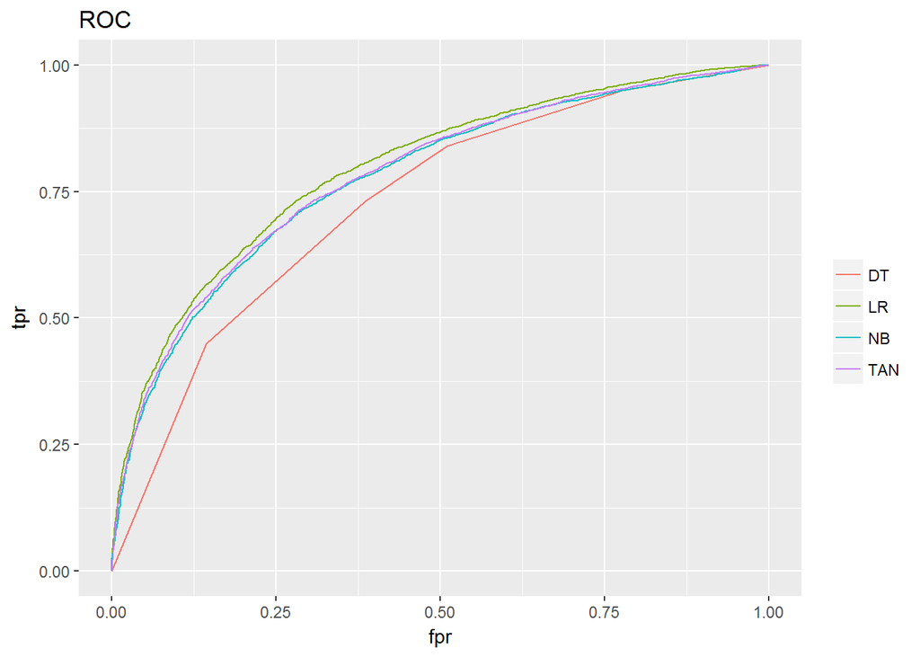

```r
rocList = list(lr = data.frame(y = lrROC@y.values[[1]],x = lrROC@x.values[[1]]),
               dt = data.frame(y = dtROC@y.values[[1]],x = dtROC@x.values[[1]]),
                 nb = data.frame(y = nbROC@y.values[[1]],x = nbROC@x.values[[1]]),
                 tan = data.frame(y = tanROC@y.values[[1]],x = tanROC@x.values[[1]]))

prList = list(lr = data.frame(y = lrPR@y.values[[1]],x = lrPR@x.values[[1]]),
               dt = data.frame(y = dtPR@y.values[[1]],x = dtPR@x.values[[1]]),
               nb = data.frame(y = nbPR@y.values[[1]],x = nbPR@x.values[[1]]),
               tan = data.frame(y = tanPR@y.values[[1]],x = tanPR@x.values[[1]]))

ggdisplay = function(data,title,xlab,ylab) {

  ggplot(data$lr, aes(x=x,y=y)) + geom_line(aes(color="LR")) +
    geom_line(data=data$dt,aes(color="DT")) +
    geom_line(data=data$nb,aes(color="NB")) +
    geom_line(data=data$tan,aes(color="TAN")) +
  coord_cartesian(xlim=c(0,1),ylim=c(0,1)) +
    xlab(xlab) + ylab(ylab) +
    ggtitle(title) +
    theme(legend.title = element_blank())

}

ggdisplay(rocList, title="ROC", xlab = "fpr", ylab = "tpr")
```

[figure not shown]

```r
ggdisplay(prList, title="PR", xlab = "prec", ylab = "rec")
```

#### Conclusions

Let’s draw conclusions from this study. Specifically,

- how well are we able to predict death or dependence at 6 months?

```r
accTbl = rbind(LR = lrAcc,DT = dtAcc,NB = nbAcc,TAN = tanAcc)
accTbl
```

```
##       TestAcc   lowerCI   upperCI
## LR  0.7337930 0.7248850 0.7425606
## DT  0.7064211 0.6972544 0.7154639
## NB  0.6937641 0.6844914 0.7029206
## TAN 0.7169171 0.7078448 0.7258592
```

> We are able to predict death or dependency at 6 months with an accuracy of ~70% for all models.
- what is the average treatment effect of aspirin on death or dependence at 6 months? Is aspirin significantly better than the alternative?

$Aspirin ATE = P(OCCODE = 1|RXASP = Y) - P(OCCODE = 1|RXASP = N)$

$Heparin ATE = P(OCCODE = 1|RXHEP = H/M/L) - P(OCCODE = 1|RXHEP = N)$

```r
asp = data %>% count(RXASP, dORd = OCCODE == 1) %>%
  mutate(p = n/sum(n)) %>%
  filter(dORd == TRUE)

hep = data %>% count(RXHEP, dORd = OCCODE == 1) %>%
  mutate(p = n/sum(n)) %>%
  filter(dORd == TRUE)

asp
```

```
## Source: local data frame [2 x 4]
## Groups: RXASP [2]
##
##    RXASP  dORd     n         p
##   <fctr> <lgl> <int>     <dbl>
## 1      N  TRUE  6125 0.6304683
## 2      Y  TRUE  6000 0.6172840
```

```r
hep
```

```
## Source: local data frame [4 x 4]
## Groups: RXHEP [4]
##
##    RXHEP  dORd     n         p
##   <fctr> <lgl> <int>     <dbl>
## 1      H  TRUE   139 0.5673469
## 2      L  TRUE  3041 0.6255914
## 3      M  TRUE  2883 0.6252440
## 4      N  TRUE  6062 0.6237909
```

```r
aspATE = asp[2,4] - asp[1,4]
hepATE = (hep[1,4]+hep[2,4]+hep[3,4])/3 - hep[4,4]

cat("aspirin ATE = ", aspATE$p, "
    \n")
```

```
## aspirin ATE =  -0.0131844
##
```

```r
cat("heparin ATE = ", hepATE$p, "
    \n")
```

```
## heparin ATE =  -0.01773012
##
```

```r
accTbl
```

```
##       TestAcc   lowerCI   upperCI
## LR  0.7337930 0.7248850 0.7425606
## DT  0.7064211 0.6972544 0.7154639
## NB  0.6937641 0.6844914 0.7029206
## TAN 0.7169171 0.7078448 0.7258592
```

> Going back to the accuracy table, the best was logistic regression, followed by TAN, decision tree, and naive bayes, although they were all close and accuracy is not the best way to compare methods. Looking at the ROC curve, logistic regression agin performed the best, while TAN and naive bayes were similar, and decision tree was clearly thr worst. This is also the same order for the PR curve. The PR curve showed that there was a large inbalance in the outcome variable, so in the future I would make sure to balance the outcome more in training and test sets. Taking all of this into account, I would say that logistic regression performed the best, while decision tree perfromed the worst.